# Итоговый проект: Рекомендательная система

Группа 16

Загружаем необходимые данные:

```r
load("~/shared/minor2_2022/data/project/ratings_g_6.RData")
load("~/shared/minor2_2022/data/project/metadata_g_6.RData")
```

### Предобработка

Мы используем текстовый анализ. Идея заключается в том, чтобы создать “рекомендательную” систему на основе LDA для пользователей, кто ещё не в системе и не оставил свой след в сервисе. Работа с датасетами ‘tags’ и ‘survey_answers’. Философия решения в том, чтобы показать фильмы, которые лучше всего соответствуют своим тегам, с высоким рейтингом и с разными жанрами. Вместо того, чтобы “рекомендовать” просто фильмы с высоким рейтингом. Помним, что у нас определенный датасет с 450 фильмами и самые высокооцененные могут быть одного жанра, например “романтика”, что может “испугнуть” нашего потенциального юзера.

0. Загрузка нужных библиотек

```r
library(LDAvis)
library(topicmodels)
library(dplyr)
library(tidytext)
library(ggplot2)
library(tidyr)
library(stringr)
```

1. Переименовыем колонку ради удобства.

```r
survey_answers_counter = survey_answers %>% group_by(score) %>% summarise(n=n())
names(survey_answers)[names(survey_answers) == 'tag_id'] <- 'id'
```

2. Создаём датасет где соединяем теги и оценки пользователей насколько теги соответсвуют фильмам.

```r
data_tags = inner_join(survey_answers, tags)
```

3. Создаём датасеты для использования LDA. Считаем колличество тегов, которые относятся к фильмам.

```r
word_counts <- data_tags %>%
  count(item_id, tag, sort = TRUE) %>%
  ungroup()
rewiew_dtm <- word_counts %>%
  cast_dtm(item_id, tag, n)
```

4. Мы полагаем, что число 8 топиков оптимально для разбиения фильмов.

```r
review2_lda <- LDA(rewiew_dtm, k = 8, control = list(seed = 12345))
```

5. Смотрим на логичность и релевантность разбиения тегов на топики.

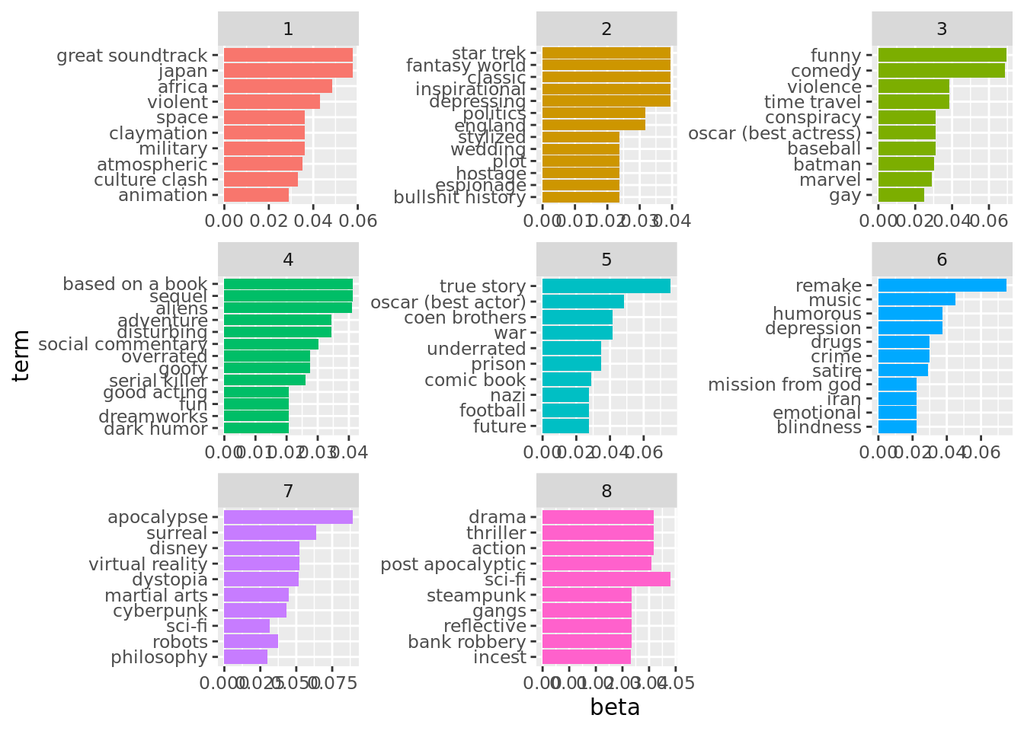

```r
review2_topics <- tidy(review2_lda, matrix = "beta")

review2_top_terms <- review2_topics %>%
  group_by(topic) %>%
  top_n(10, beta) %>%
  ungroup() %>%
  arrange(topic, -beta)


review2_top_terms %>%
  mutate(term = reorder(term, beta)) %>%
  ggplot(aes(term, beta, fill = factor(topic))) +
  geom_col(show.legend = FALSE) +
  facet_wrap(~ topic, scales = "free") +
  coord_flip()
```

Делаем вывод, то разбиение прошло “логично”, хоть и неидеально. Например, great soundtrack и atmospheric, находятся в одном топике. Funny и comedy в одном топике. Crime и drugs также в одном топике. Однако, есть и не самые “логичные” разбиения, например, star trek и bullshit history.

6. Смотрим на вероятность того, что определенный фильм находится в определенном топике

```r
review_documents <- tidy(review2_lda, matrix = "gamma")
head(review_documents)
```

```
## # A tibble: 6 × 3
##   document topic   gamma
##   <chr>    <int>   <dbl>
## 1 1            1 0.950
## 2 318          1 0.00772
## 3 110          1 0.961
## 4 316          1 0.712
## 5 319          1 0.0206
## 6 356          1 0.00717
```

7. Оставляем только те фильмы, которые имеют вероятность попасть в определенных топик больше 0.6

```r
preferredTopic = review_documents %>% group_by(document) %>% arrange(-gamma) %>% filter(gamma>0.60)
```

8. Создаём датасет в котором будет топ-20 фильмов по рейтингу соответсвия тэгов к фильму, суммируем этот рейтинг.

```r
best_films_tags = survey_answers %>% group_by(item_id) %>% summarise(sum = sum(score)) %>% top_n(20,sum) %>% arrange(-sum)
```

9. Обрабатыем данные и изменяем тип переменных.

```r
names(preferredTopic)[names(preferredTopic) == 'document'] <- 'item_id'
best_films_tags$item_id = as.double(best_films_tags$item_id)
preferredTopic$item_id = as.double(preferredTopic$item_id)
```

10. Объединяем датасеты

```r
topList = inner_join(preferredTopic,best_films_tags)
recommend_new = inner_join(metadata, topList)
```

11. Смотрим на результат.

```r
recommend_new$title
```

```
##  [1] "Beautiful Mind, A (2001)"
##  [2] "Matrix, The (1999)"
##  [3] "American Beauty (1999)"
##  [4] "Twelve Monkeys (a.k.a. 12 Monkeys) (1995)"
##  [5] "Dark Knight, The (2008)"
##  [6] "Clerks (1994)"
##  [7] "Shawshank Redemption, The (1994)"
##  [8] "Sixth Sense, The (1999)"
##  [9] "Office Space (1999)"
## [10] "Full Monty, The (1997)"
## [11] "Batman Begins (2005)"
## [12] "Fight Club (1999)"
## [13] "Usual Suspects, The (1995)"
## [14] "Sideways (2004)"
## [15] "Kill Bill: Vol. 1 (2003)"
## [16] "Titanic (1997)"
## [17] "Braveheart (1995)"
## [18] "Schindler's List (1993)"
## [19] "People vs. Larry Flynt, The (1996)"
## [20] "Matrix Reloaded, The (2003)"
```

Итог. Вроде получилось неплохо: разные жанры, разные фильмы, узнаваемые и с высоким рейтингом. Такая подборка может соблазнить нового юзера остаться в нашем сервисе.

### Коллаборативная фильтрация

Логика работы системы:

1. ввод: id пользователя
2. используемый метод UBCF:Поиск пользователей с похожими средними оценками фильмов режиссёров; определение режиссера, чьи фильмы с большей вероятностью понравятся пользователю
3. вывод: спискок из фильмов определенного режиссера, основываясь на оценке
0. Предварительная подготовка данных

Так как мы мы будем рекомендовать 10 фильмов одного режиссера (который рекомендуется системой), создаем датасет с информацией о пользователе, id режиссера и оценкой его фильма

0.1. Создаем колонку с id режиссёра

```r
for_content = separate_rows(metadata, directedBy, convert = TRUE, sep = ', ')
for_content <- for_content %>% mutate(director_id = as.numeric(match(for_content$directedBy, unique(for_content$directedBy))))
```

0.2. Соединяем таблицу с информацией о пользователях и их оценках и таблицу с id режиссёров, оставляем только нужные переменные

```r
ratings_d = for_content %>% inner_join(ratings) %>% select(user_id, rating, director_id)
head(ratings_d)
```

```
## # A tibble: 6 × 3
##   user_id rating director_id
##     <dbl>  <dbl>       <dbl>
## 1  763022    1             1
## 2  738929    5             1
## 3   81774    3             1
## 4  275435    5             1
## 5  934929    4.5           1
## 6  290177    4.5           1
```

0.3. Считаем количество оценок, поставленных человеком одному режиссёру

```r
counts <- ratings_d %>% count(user_id, director_id)
```

```r
ratings_d_counts = ratings_d %>% inner_join(counts) %>% filter(n <= 2)
```

0.5. Считаем среднюю оценку человека по каждому режссёру

```r
ratings_df = ratings_d_counts %>% group_by(user_id, director_id) %>% summarise(rating_m = mean(rating)) %>% ungroup()
ratings_df$user_id = as.character(ratings_df$user_id)
head(ratings_df)
```

```
## # A tibble: 6 × 3
##   user_id director_id rating_m
##   <chr>         <dbl>    <dbl>
## 1 133               5        5
## 2 133              30        5
## 3 133              46        4
## 4 133             104        5
## 5 133             105        5
## 6 133             116        5
```

0.6. Преобразуем к таблице в “широком” формате

```r
rates = pivot_wider(ratings_df, names_from = director_id, values_from = rating_m)
```

0.7. Сохраним id пользователей и удалим столбец с id пользователей

```r
userNames = rates$user_id
rates = select(rates, -user_id)
library(recommenderlab)
```

0.8. Преобразуем данные с оценками в формат, где используются численные оценки — realRatingMatrix.

```r
rates = as.matrix(rates)
rownames(rates) = userNames
r = as(rates, "realRatingMatrix")
```

0.9. Вычислим похожесть всех пар

```r
similarity_directors <- similarity(r[], method = "cosine", which = "users")
```

0.10 Разделим данные на тестовую и обучающую выборки. Делаем рандом фиксированным, чтобы выборки всегда получались одинаковыми

```r
set.seed(100)
test_ind <- sample(1:nrow(r), size = nrow(r)*0.2)
recc_data_train <- r[-test_ind, ]
recc_data_test <- r[test_ind, ]
```

**1.0 Создадим рекомендательную модель, используя метод UBCF**

Система содержит отношения пользователи-режиссеры-средние оценки фильмов режиссеров

```r
recc_model <- Recommender(data = recc_data_train, method = "UBCF")

recc_predicted <- predict(object = recc_model, newdata = recc_data_test, n = 1)
names(recc_predicted@items) = rownames(recc_data_test)
```

**2. Функция рекомендательной системы**

```r
getfilmCF = function(id) {
  person = ratings_df %>% filter(user_id == id & rating_m > 3.5)
  if (nrow(person) >= 2) {
      recc_predicted <- predict(object = recc_model, newdata = r, n = 1)
      recc_user <- recc_predicted@items[[id]]
      director_user <- recc_predicted@itemLabels[recc_user]
      names_directors_user <- for_content$directedBy[match(director_user, for_content$director_id)]
      names_directors_user
      film = for_content %>% filter(directedBy == names_directors_user)
      film$title
      names_directors_user
      film

  } else {
    print("Мало положительных оценок для персонализрованной рекомендации")
    recommend_new$title
  }}
```

**Оценивание рекомендации:**

1. Проверка по параметрам RMSE, MSE и MAE

```r
set.seed(100)
eval_sets <- evaluationScheme(data = r,
                              method = "split",
                              train = 0.8, # доля обучающей выборки
                              given = 15, # сколько оценок используется для  предсказания
                              goodRating = 4) # если предсказанная оценка < 4, то фильм не рекомендуем
```

```r
recc_predicted = predict(
  object = recc_model,
  newdata = getData(eval_sets, "known"),
  n = 1,
  type = "ratings")

eval_accuracy_ubcf = calcPredictionAccuracy(
  x = recc_predicted,
  data = getData(eval_sets, "unknown"),
  byUser = F)

eval_accuracy_ubcf
```

```
##      RMSE       MSE       MAE
## 1.0447993 1.0916055 0.8136771
```

Значение RMSE равно 1.0447993, что означает, что среднее отклонение между реальными и предсказанными значениями составляет около 1. MSE равно 1.0916055, так же показывает среднее отклонение ( с учетом положительных и отрицательных) равное примерно 1. Это может быть хорошим показателем. MAE равно 0.8136771. Среднее абсолютное отклонение между реальными и предсказанными значениями составляет даже меньше - около 0.8. Все эти метрики значительно улучшились с тестирования первоначальной версии системы, где режиссёры не были поделены, если их было несколько на один фильм.

2. Проверка на адекватность

Выберем пользователя с id - 133 и составим ему рекомендацию.

```r
getfilmCF(133)
```

```
## # A tibble: 1 × 7
##   title              directedBy  starring   avgRating imdbId item_id director_id
##   <chr>              <chr>       <chr>          <dbl> <chr>    <int>       <dbl>
## 1 Hoop Dreams (1994) Steve James Arthur Ag…      4.00 01100…     246         339
```

“Hoop Dreams” - американский документальный фильм 1994 года режиссера Стива Джеймса. Фильм о жизни двух мальчиков из Чикаго, живущих в глубинке, которые пытаются стать баскетболистами колледжа на пути к профессиональной карьере. Жанры этого фильма: драма, спорт, документалистика.

Теперь посмотрим на оценнённые фильмы этим пользователем.

```r
top5 = ratings_d %>%
  filter(user_id == 133) %>%
  top_n(5, rating) %>%
  inner_join(for_content, by = "director_id")
```

Также посмотрим на режиссеров, т.к. это специфика нашей системы.

Режиссер, Стива Джеймс, рекомендованного фильма “Hoop Dreams”, в основном снимал документальное остросюжетное кино. Среди понравившихся режиссеров, документлистов нет. Однако те режиссеры, кого пользователь больше всего смотрел и оценивал - Кристофер Нолан и Квентин Тарантино -тоже снимали остросюжетное кино.

Также можно заметить, что просмотренные пользователем фильмы - одни из самых популярных, а система порекомендовала что-то более авторское, а также снятое до 2000 года (хотя все понравившиеся сняты позже). Эти критерии могут указывать на небольшой недостаток системы. Однако, она опирается на оценки другими пользователями, и таким образом можно предположить, что людям с похожими вкусами, нравится документалистика, но сам пользователь никогда не смотрел подобные фильмы.

Можно сделать вывод, что рекомендация работает неплохо, может показать альтернативное кино, который человек не видел, но может потенциально понравиться.

### Content-based рекомендация

Логика работы системы:

0.1 Создадим датафрейм для построения рекомендации, объединяющий все необходимые характеристики, - сделаем из каждого уникального значения режиссера и трех актеров главной роли новые столбцы, со значениями 1 - есть в фильме, 0 - нет

```r
moviesforCB = metadata %>% dplyr::select(title, item_id, directedBy, starring)
moviesforCB$starring = strsplit(moviesforCB$starring, ",")
moviesforCB$new_columns <- str_split(moviesforCB$starring, ",\\s*")

moviesforCB$first_name <- sapply(moviesforCB$new_columns, function(x) x[1])
moviesforCB$second_name <- sapply(moviesforCB$new_columns, function(x) x[2])
moviesforCB$third_name <- sapply(moviesforCB$new_columns, function(x) x[3])
moviesforCB$starring <- NULL
moviesforCB$new_columns <- NULL

moviesforCB$v = rep(1, nrow(moviesforCB))
moviesforCB = spread (moviesforCB, directedBy, v, 0)
moviesforCB$v1 = rep(1, nrow(moviesforCB))
moviesforCB = spread (moviesforCB, first_name, v1, 0 )
moviesforCB$v2 = rep(1, nrow(moviesforCB))
moviesforCB = spread (moviesforCB, second_name, v2, 0 )
moviesforCB$v3 = rep(1, nrow(moviesforCB))
moviesforCB = spread (moviesforCB, third_name, v3, 0 )
rownames = moviesforCB$item_id
rownames(moviesforCB) = rownames
moviesforCB = moviesforCB %>% dplyr::select(-item_id, -title)
```

0.2. Создаем матрицу схожести

```r
sim = lsa::cosine(t(as.matrix(moviesforCB)))
diag(sim) = 0
```

1. Функция рекомендательной системы content-based

```r
rec_movies = function(id, k){
    sim = sim[,as.character(id)]
    mostSimilar = head(sort(sim, decreasing = TRUE), n = k)
    a = t(mostSimilar)
    result = colnames(a)
    recommend = filter(metadata, item_id %in% result) %>% dplyr::select(title)
     if (length(recommend$title) < k){
       recommend1 = filter(metadata,item_id %in% result) %>% dplyr::select(title)
       recommend2 =  recommend_new[1:(k-nrow(recommend)), ] %>% select(title)
       recommend = recommend1 %>% full_join(recommend2)
  }
 recommend
}
```

2. Проверка на адекватность

Для оценивания качества наших рекомендаций мы остановились на внутренней пользовательской оценке - для Content-Based системы она показалась нам наиболее оптимальной. В ее применении нам помогли в том числе примеры из peer review - рассмотрим несколько случаев:

2.1.Укажем фильм “Великий Гэтсби” - зная, что в нашей выборке нет других фильмов с таким же режиссером, мы ожидаем увидеть фильмы с похожими актерами в главных ролях:

```r
rec_movies(102407, 5)
```

```
##                   title
## 1  Departed, The (2006)
## 2 Shutter Island (2010)
## 3   The Revenant (2015)
## 4      Inception (2010)
## 5        Titanic (1997)
```

Действительно, во всех этих примерах есть хотя бы один совпадающий актер главной роли.

2.2. Проведем аналогичную операцию для ситуации, когда у режиссера фильма, который мы вводим, много фильмов в датасете. Для остроты ситуации выберем такого режиссера, который не только снимал, но и сам был в одной из главных ролей в каком-либо фильме - например, Квентина Тарантино. Возьмем его фильм Kill Bill: Vol. 1 (2003)

```r
rec_movies(6874, 3)
```

```
##                         title
## 1 Inglourious Basterds (2009)
## 2     Django Unchained (2012)
## 3    The Hateful Eight (2015)
```

Действительно, во всех этих фильмах Квентин либо был режиссером, либо актером!

Эти и показанные в разделе peer review ответы, как мы считаем, подтверждают адекватность нашей системы - несмотря на очень ограниченную выборку, она действительно выдает результаты, имеющие общие характеристики с введенным фильмом (при их наличии).

### Примеры

##### Примеры collaborative filtering

Пример 1. Случай, когда у пользователя мало положительных оценок: пользователь функции будет уведомлен о малом количестве положительных оценок и, ему будет выведен список из фильмов, основанный на оценках и популярности тэга (текстовый анализ).

```r
getfilmCF(1668)
```

```
## [1] "Мало положительных оценок для персонализрованной рекомендации"
```

```
##  [1] "Beautiful Mind, A (2001)"
##  [2] "Matrix, The (1999)"
##  [3] "American Beauty (1999)"
##  [4] "Twelve Monkeys (a.k.a. 12 Monkeys) (1995)"
##  [5] "Dark Knight, The (2008)"
##  [6] "Clerks (1994)"
##  [7] "Shawshank Redemption, The (1994)"
##  [8] "Sixth Sense, The (1999)"
##  [9] "Office Space (1999)"
## [10] "Full Monty, The (1997)"
## [11] "Batman Begins (2005)"
## [12] "Fight Club (1999)"
## [13] "Usual Suspects, The (1995)"
## [14] "Sideways (2004)"
## [15] "Kill Bill: Vol. 1 (2003)"
## [16] "Titanic (1997)"
## [17] "Braveheart (1995)"
## [18] "Schindler's List (1993)"
## [19] "People vs. Larry Flynt, The (1996)"
## [20] "Matrix Reloaded, The (2003)"
```

Пример 2.Случай, когда у пользователя достаточно положительных оценок: пользователь функции получит персонализированные рекомендации. При этом человек получит не только название фильмов, но и режиссера, имена актёров и средние оценки на популярных платформах.

```r
getfilmCF(446)
```

```
## # A tibble: 1 × 7
##   title          directedBy   starring      avgRating imdbId item_id director_id
##   <chr>          <chr>        <chr>             <dbl> <chr>    <int>       <dbl>
## 1 Get Out (2017) Jordan Peele Daniel Kaluu…      3.99 50524…  168250         205
```

##### Примеры content-based

Пример 1. Выведем рекомендации для фильма Goodfellas (1990)

```r
rec_movies(1213, 7)
```

```
##                     title
## 1       Awakenings (1990)
## 2        Limitless (2011)
## 3 Meet the Fockers (2004)
## 4    Departed, The (2006)
## 5 Meet the Parents (2000)
## 6  Lethal Weapon 3 (1992)
## 7    Bronx Tale, A (1993)
```

Пример 2. Выведем рекомендации для фильма Beautiful Mind, A (2001)

```r
rec_movies(4995, 5)
```

```
##                                                       title
## 1                                 Da Vinci Code, The (2006)
## 2                                    Angels & Demons (2009)
## 3                                     Gone Baby Gone (2007)
## 4                                         Robin Hood (2010)
## 5 How the Grinch Stole Christmas (a.k.a. The Grinch) (2000)
```

### Ответы на вопросы и разбор примеров из peer review

**Вопросы к предобработке данных и LDA**

1. После просмотра видео команды, у меня возник вопрос к выделению тем по тегам. Так как выборка тегов небольшая по размеру и сами теги не подходят по анализ при помощи алгоритма LDA, так как теги - это отдельные слова, а не связный текст.

*Ответ*: Как было сказано в видео, не существует универсального способа по расчету оптимального количества топиков. Начиная с 5 и до 12, мы решили остановиться на 8, потому как при этом разбиении происходили лучшие группировки тегов по смыслу в одном топике

2. ““Далее создаем датасет с топ-20 фильмов, которые соответствуют тегам”“. Насколько я поняла, речь про те фильмы, у которых была высокая оценка соответствия тегам. А почему 20?

*Ответ*: Это число мы тоже пытались “найти” и топ фильмов тоже постоянно регулировался пока мы не получили оптимальный результат, где в итоге встретились самые разные фильмы, которые в теории могут заинтересовать нового пользователя. Если брать меньше, то нужно помнить про вторую фильтрацию по gamma, и на выход получается слишком мало фильмов. Если брать больше, то “рекомендация” для нового пользователя слишком большая

3. Не услышала ничего про сетевой анализ, про некоторые части текстового. Интересно, ребята просто не стали их делать по какой-то причине или не посчитали результаты релевантными?”

*Ответ*: Сетевой анализ не показался нам настолько полезным для нашей работы, как LDA, который, как нам кажется, отлично вписался и “подарил” нам рекомендацию для пользователей, которые не оставили следа в системе. Мы пробовали применить сеть, но ни один из способов не был идеальным и везде можно было найти просадки в логике, которые могли только подтолкнуть нас к ложным выводам.

**Вопросы с CF системе**

1. По CF - что будет выводить система для абсолютно нового пользователя, который не оценивал фильмы?

*Ответ*: Для этого используется топ фильмов, у которых наиболее высокая оценка соответствия тегам, новому пользователю рекомендуются фильмы из этого топа.

2. Не понятно, зачем нужно 2 системы КФ: следует остановиться на одной из них. Также не понятно, почему 1-я система считается приоритетной, если сами участники команды говорят, что она выдает менее качественные рекомендации.

**Вопросы к CB системе**

1.Вроде интересно, что можно фиксировать сколько фильмов рекомендованных я хочу получить, но непонятно зачем (если их будет мало в базе, то все равно столько не покажет, ну и в целом зачем?).

Ответ: Фиксация количества рекомендаций представляется нам оптимальным решением, так как могут быть разные сценарии взаимодействия клиента и системы: кто-то может искать очень похожий фильм и его таким образом будет интересовать конкретно самый похожий по ряду характеристик вариант, а чья-то цель просто найти новый хороший фильм, который бы ему понравился - тогда он может выбирать большее значение вывода, чтобы было из чего выбрать.

2.1 Не оценили адекватность выданных рекомендаций, насколько ок работает ваша система с вашей точки зрения? 2.2 Интересно, как ребята хотят оценить content-based систему”

Ответ: С нашей точки зрения система со своей задачей - определение наиболее похожих вариантов на введенный фильм справляется успешно. Для оценки адекватности рекомендаций нами используется внутренняя пользовательская оценка

3. “Как конкретно работает рекомендация CB систем? Конкретно - каким образом вычисляется вес характеристик при рекомендации?”

Ответ: Наша CB система выводит рекомендации на основании схожести фильмов по режиссеру (или режиссерам, если их несколько) и трем актерам главной роли. В используемой нами матрице схожести каждая из этих характеристик имеет одинаковый вес.

4. “Не было сказано, каким образом были предобработаны данные для проведения content-based анализа, пробовали ли какие-то другие варианты анализа кроме LDA”

Ответ: Для построения Content-Based системы мы преобразовали исходный датасет. Во первых, в колонке с актерами, играющими в фильме, было оставлено только по 3 актера главной роли для каждого фильма (мы предполагаем, что актеры расположены по убыванию их “важности”, т.к. это стандартная практика для всех ресурсов и они в нашем датасете точно не расположены по алфавиту. Кроме того, убедиться в том, что это действительно актеры главной роли помогла ручная проверка этого факта для нескольких фильмов из выборки), а затем преобразовано в три разных столбца с колонкой на актера. Далее мы перевели все уникальные значения из столбцов с режиссерами и актерами в названия новых столбцов и сделали бинарное кодирование: значение 1 если этот актер/режиссер есть в соответствующем фильме, 0 - если нет

**Примеры**

1.1.Было бы интересно проверить рекомендательную систему по людям, которым нравится определенный актёр (например, Robert De Niro). Выдаст ли система фильмы только по этому актеру или будут выдаваться случае с его коллегами (теми, с кем он работал в одном фильме). Так же в видео не упоминался случай рассмотрения сценария для пользователя, у кторого нет рекомендаций, поэтому было бы интересно протеститровать и его.

1.2.Пусть будет юзер, которому нравится фильм Один дома -> показывает другие части одного дома + Богатенький Риччи (тот же актер и тематика)

Ответ: нашей системой напрямую не предусмотрена такая возможность, но можем предположить, что тогда такой пользователь введет в Content-Based систему фильм с Робертом Де Ниро (фильма Один дома и Маколея Калкина в датасете нет, поэтому в качестве примера используем фильм с Робертом Де Ниро):

```r
rec_movies(3105, 3)
```

```
##                     title
## 1        Limitless (2011)
## 2 Meet the Fockers (2004)
## 3 Meet the Parents (2000)
```

Действительно, система выдала те фильмы, в которых он тоже снимался! Однако есть вероятность, что будут посоветованы и фильмы с его коллегами, в том случае, если режиссер фильма будет совпадать. Без этого такое невозможно - в процессе предобработки данных для посотрения матрицы схожести для каждого актера предусмотрен отдельный столбец и отследить их совместные появления не представляется возможным.

2.1.Меня заинтересовал способ с рекомендацией по режиссерам) Мне вот очень нравятся Стражи Галактики в том числе и из-за стиля режиссера, и, думаю, я бы ставила фильмам этой серии хорошие оценки. В таком случае интересно, порекомендовала ли бы система для меня другие фильмы Джеймса Ганна… Ожидаю, что порекомендовала бы)

2.2.Допустим, чтобы по «Репетиции оркестра» выпадало топ-5 фильмов Феллини

2.3. Что выдаст система, если я укажу любимого режиссера как Эндрю Адамсон

Ответ: рассмотрим пример для фильма “Стражи Галактики” (т.к. ни “Репетиции оркеста”, ни фильмов Феллини у нас нет, ни фильмов Эндрю Адамсона). В нашем датасете только два фильма этого режиссера, поэтому посмотрим, какой фильм порекомендуется в ответ на первую часть Стражей Галактики:

```r
rec_movies(112852, 1)
```

```
##                              title
## 1 Guardians of the Galaxy 2 (2017)
```

Действительно, система выдала фильм того же режиссера!

3. Что система порекомендует пользователю в случае, если все просмотренные им фильмы - фильмы одного режиссера и каждому из них пользователь поставил плохую оценку.

Рассмотрим на примере:

```r
# сгруппируем наборы данных по пользователю и подсчитаем количество уникальных режиссёров, которые он оценил
df_count <- ratings_d %>%
  group_by(user_id) %>%
  summarise(num_directors = n_distinct(director_id))

# выбрем пользователей, которые смотрели фильмы, снятые только одним режиссером
df_single_director <- df_count %>%
  filter(num_directors == 1)

head(df_count) %>% arrange(num_directors)
```

```
## # A tibble: 6 × 2
##   user_id num_directors
##     <dbl>         <int>
## 1     446             6
## 2     779             7
## 3     133             9
## 4     591             9
## 5     985            13
## 6     754            29
```

2. По логике нашей модели, если человек имеет только низко-оценненных режиссеров, без зависимости от их количества, пользователю будет выдаваться универсальная рекомендация, т.к. он имеет недостаточно положительных оценок в любом случае.

**Вопросы, оставшиеся без ответов** 1. Так как вторая система по id фильма, я бы хотела посмотреть, Что будет, если я хочу посмотреть фильмы, похожие на Автостопом по галактике? Количество - 4. Я ожидаю, что система порекомендует фильмы, которые будут фантастическими и с темой космоса (например, звездные воины, что-нибудь такое)

**Причина:** Данного фильма нет в системе, чтобы привести конкретный результат. Более того, топики не обязательно относятся к жанру и теме фильма, поэтому мы не можем привести аналогичный пример для этого случая.

2. Например, если пользователь хорошо оценит фильм Джуманджи, система может порекомендовать ему фильм Парк юрского периода 3. Система cb ищет схожие фильмы по режиссерам, актерам 3 главных героев фильма, тематике на основе выделенных тем lda, средней оценке. Эти два фильма имеют одного и того же режиссёра, примерно одинаковый рейтинг, и тематика скорее всего окажется близкой, но разный актёрский состав.

**Причина:** Данного фильма нет в системе, чтобы проверить, действительно ли в качестве результата будет выдан Парк юрского периода 3 из-за большого количества схожести характеристик. Более того, средняя оценка фильма не учитывается в нашей системе.

3. “Я бы хотел проверить content-based систему, например, если бы был введен такой фильм, как”“Маленькая Вера”“.

**Причина:** данного фильма нет в нашей системе, при этом он обладает достаточно специфичными характеристиками для приведения аналогичных примеров - это советский фильм 1988 года с режиссёром Василием Пичула, где в главных ролях снимались Наталья Негода, Андрей Соколов и Людмила Зайцева. Ни одной из этих характеристик нет в фильмах из нашего датасета, поэтому предоставление примеров оказывается невозможным.

### Сценарий

Порекомендуйте что-то пользователю, у которого доля оцененных фильмов в теме 2 максимальна и при этом оценено не меньше трех фильмов (например, у него 100% его фильмов из темы 2, а у остальных пользователй меньше). Рекомендуются ли ему фильмы из этой же темы?

1 Cоздадим датасет с айди фильмами и распределниям их по темам.

```r
scenario_test = inner_join(metadata, preferredTopic)
scenario_test = scenario_test %>% select(title, item_id, topic)
```

2 Cоздадим датасет с распредленными по темам фильмами и их оценками пользователей.

```r
rating_test1 = inner_join(scenario_test, ratings)
```

3 Найдем пользавтеля с наибольшим количеством оценок в теме 2.

```r
rating_test = rating_test1 %>% filter(topic==2) %>% group_by(user_id) %>% summarise(counter = n() )
rating_test = rating_test %>% arrange(-counter)
head(rating_test)
```

```
## # A tibble: 6 × 2
##   user_id counter
##     <dbl>   <int>
## 1  411019       7
## 2  320576       5
## 3  389470       5
## 4  446511       5
## 5  665348       5
## 6   57309       4
```

4 Но возникает проблема, что для него рекомендательная система не может выдать рекомендацию (в других темах была такая же проблема для первого пользователя)

```r
recc_model <- Recommender(data = recc_data_train, method = "UBCF")

recc_predicted <- predict(object = recc_model, newdata = recc_data_test, n = 1)
names(recc_predicted@items) = rownames(recc_data_test)
recc_user <- recc_predicted@items[['411019']]
director_user <- recc_predicted@itemLabels[recc_user]
names_directors_user <- for_content$directedBy[match(director_user, for_content$director_id)]
names_directors_user
```

```
## character(0)
```

5 Перебрав других пользователей, найдем пользователя,для которого рекомендация выдается и есть 4 оценки в теме 2 проверяем не в функции потому что для функции недостаточно положительных оценок b тогда вообще не будет никакой рекомендации

```r
recc_user <- recc_predicted@items[['246818']]
director_user <- recc_predicted@itemLabels[recc_user]
names_directors_user <- for_content$directedBy[match(director_user, for_content$director_id)]
names_directors_user
```

```
## [1] "Steve James"
```

```r
film = for_content %>% filter(directedBy == names_directors_user)
film$title
```

```
## [1] "Hoop Dreams (1994)"
```

```r
names_directors_user
```

```
## [1] "Steve James"
```

```r
film
```

```
## # A tibble: 1 × 7
##   title              directedBy  starring   avgRating imdbId item_id director_id
##   <chr>              <chr>       <chr>          <dbl> <chr>    <int>       <dbl>
## 1 Hoop Dreams (1994) Steve James Arthur Ag…      4.00 01100…     246         339
```

6 Найдем какому топику принадлежит этот фильм Оказалось что он пренадлежит 3 теме. Это может быть связано с тем что мы выбрали человека только с 4 оценками в теме, так как для других рекомендация не строилась.

```r
scenario_test %>% filter(item_id == 246 )
```

```
##                title item_id topic
## 1 Hoop Dreams (1994)     246     3
```

Фильмы рекомендуемые пользователю находяться в разных топиках.